## **Input: Gene Information**

Completed on Tue Aug 29 16:40:39 2023 (Asia/Shanghai), with the runtime of 4 seconds.

> **An interactive table** for user-input genes (n=278, being processed). The table includes two columns: 1st column `Genes` for gene symbols, and 2nd column `Description` for gene description.

| Genes | Description |
| --- | --- |
| Ank1 | ankyrin 1, erythroid |
| Ap4s1 | adaptor-related protein complex AP-4, sigma 1 |
| Apobec2 | apolipoprotein B mRNA editing enzyme, catalytic polypeptide 2 |
| Arg2 | arginase type II |
| Asgr1 | asialoglycoprotein receptor 1 |
| Bub1b | BUB1B, mitotic checkpoint serine/threonine kinase |
| Ccnd2 | cyclin D2 |
| Cish | cytokine inducible SH2-containing protein |
| Dpysl2 | dihydropyrimidinase-like 2 |
| Cyp19a1 | cytochrome P450, family 19, subfamily a, polypeptide 1 |

[output cut: 268 more lines]

## **Output: Enriched Terms**

> **An interactive table** that displays enriched ontology terms. Each enriched term (the columns `Ontology`, `Term ID`, and `Term Name`) has the enrichment Z-score (`Z-score`), the significance level of the enrichment (`FDR`), odds ratio (`Odds ratio`) and 95% confidence intervals (`95% CI`), the number (`Num`) and list (`Members`) of member genes that overlap with your input genes. The table is sorted by FDR ascendingly.

| Ontology | Term ID | Term Name | Z-score | FDR | Odds ratio | 95% CI | Num | Members |
| --- | --- | --- | --- | --- | --- | --- | --- | --- |
| Biological Process | GO:0010811 | positive regulation of cell-substrate adhesion | 5.88 | 0.02 | 6.13 | [2.7, 12.2] | 9 | Cspg5, Dock5, Fbln1, Fbln2, Itgb1bp1, Itgb3, Prex1, Spp1, Vit |
| Biological Process | GO:1900024 | regulation of substrate adhesion-dependent cell spreading | 6.5 | 0.02 | 9.96 | [3.46, 23.5] | 6 | Cspg5, Dock5, Fbln1, Itgb1bp1, Itgb3, Prex1 |
| Biological Process | GO:0010810 | regulation of cell-substrate adhesion | 5.26 | 0.02 | 4.57 | [2.21, 8.53] | 11 | Cspg5, Dock5, Fbln1, Fbln2, Itgb1bp1, Itgb3, Mmp14, Prex1, Rac2, Spp1, Vit |
| Biological Process | GO:0051649 | establishment of localization in cell | 3.68 | 0.086 | 1.96 | [1.32, 2.83] | 36 | Ank1, Ap4s1, Arhgef2, Bcr, Bloc1s6, Dpysl2, Ehd3, Fnbp1l, Grn, Heatr5a, Heatr5b, Ing1, Kcnip3, Lmnb2, Lrp2, Map1a, Micall1, Mttp, Myo7b, Nup210, Pinx1, Pkd2, Scfd1, Slc17a6, Slc17a9, Slc30a6, Slc6a4, … |
| Biological Process | GO:0032026 | response to magnesium ion | 6.66 | 0.086 | 20.4 | [3.7, 75.1] | 3 | Kcna1, Kcnip3, Slc41a1 |
| Biological Process | GO:0060263 | regulation of respiratory burst | 6.44 | 0.086 | 18.9 | [3.46, 68.7] | 3 | Bcr, Grn, Rac2 |
| Biological Process | GO:0030540 | female genitalia development | 6.23 | 0.086 | 17.7 | [3.26, 63.2] | 3 | Cyp19a1, Lrp2, Stra6 |
| Biological Process | GO:0008104 | protein localization | 3.45 | 0.086 | 1.9 | [1.27, 2.78] | 34 | Ank1, Ap4s1, Bcr, Bloc1s6, Bub1b, Dlgap1, Ehd3, Fras1, Frmpd1, Heatr5a, Heatr5b, Hectd1, Ing1, Itgb1bp1, Kcna1, Kcnip3, Lamp3, Lmnb2, Lrp2, Map1a, Mapk10, Micall1, Mms22l, Mttp, Phyhip, Pinx1, Pkd2, P… |
| Biological Process | GO:0070727 | cellular macromolecule localization | 3.43 | 0.086 | 1.9 | [1.27, 2.77] | 34 | Ank1, Ap4s1, Bcr, Bloc1s6, Bub1b, Dlgap1, Ehd3, Fras1, Frmpd1, Heatr5a, Heatr5b, Hectd1, Ing1, Itgb1bp1, Kcna1, Kcnip3, Lamp3, Lmnb2, Lrp2, Map1a, Mapk10, Micall1, Mms22l, Mttp, Phyhip, Pinx1, Pkd2, P… |
| Biological Process | GO:0006897 | endocytosis | 3.78 | 0.086 | 2.86 | [1.48, 5.06] | 13 | Bcr, Dpysl2, Ehd3, Fnbp1l, Grn, Heatr5a, Heatr5b, Itgb3, Lrp2, Lrp8, Micall1, Scara5, Spg11 |

[output cut: 916 more lines]

## **Output: Dotplot**

> **A dotplot** of enriched ontology terms identified using Fisher’s exact test. An editable pdf file is also available for download.

DOWNLOAD .pdf

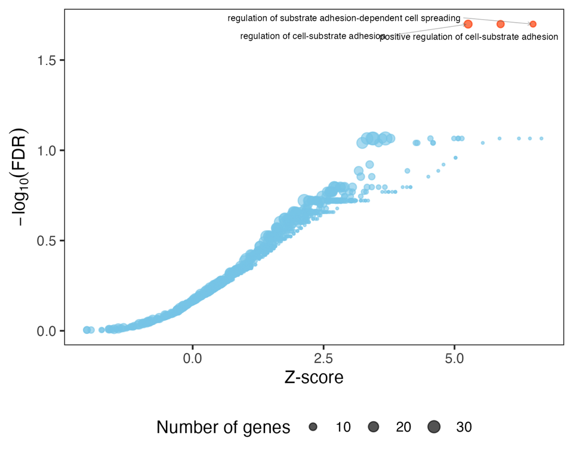

## **Output: Forest Plot**

> **A forest plot** of enriched ontology terms identified using Fisher’s exact test. An editable pdf file is also available for download.

DOWNLOAD .pdf

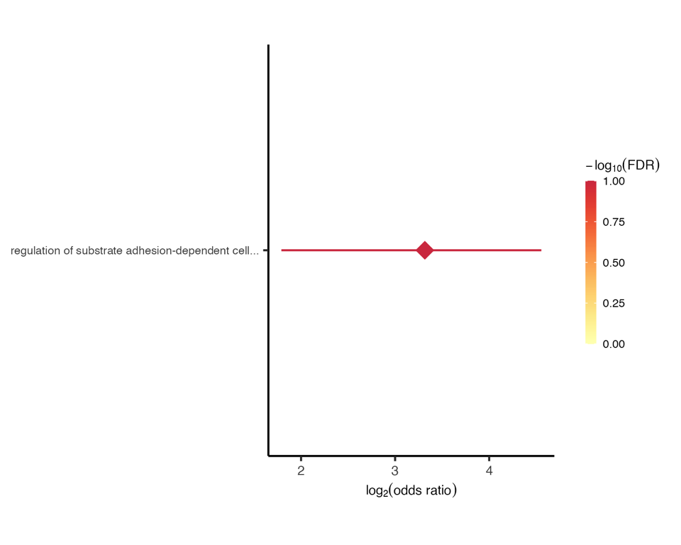

Figure 2: Forest plot for enriched ontology terms (ordered by odds ratio descendingly).